# Stats506 Hw2

Author

Lingqi Huang

Github : https://github.com/KingOliver666/HW-.git

## Problem 1

part(a):

Version1:

```r
play_dice1 <- function(n){
  dice_number <- 1 : 6
  sum <- 0
  trials <- sample(dice_number, size = n, replace = TRUE)
  trials[trials == 1] <- -2
  trials[trials == 2] <- 0
  trials[trials == 3] <- -2
  trials[trials == 4] <- 2
  trials[trials == 5] <- -2
  trials[trials == 6] <- 4
  for (i in 1: n){
    sum <- sum + trials[i]
  }
  return (sum)
}
play_dice1(10)
```

```
[1] 6
```

Version2:

```r
play_dice2 <- function(n){
  trials <- sample(1: 6, size = n, replace = TRUE)
  trials[trials == 1] <- -2
  trials[trials == 2] <- 0
  trials[trials == 3] <- -2
  trials[trials == 4] <- 2
  trials[trials == 5] <- -2
  trials[trials == 6] <- 4
  return(sum(trials))
}
play_dice2(10)
```

```
[1] -10
```

Version3:

```r
play_dice3 <- function(n){
  cost <- 2
  dice_rolls <- sample(1:6, n, replace = TRUE)
  outcome_table <- table(factor(dice_rolls, levels = 1:6))


  gain <- 2 * as.integer(outcome_table["2"]) + 4 * as.integer(outcome_table["4"]) + 6 * as.integer(outcome_table["6"]) - (cost * n)

  return(gain)
}

play_dice3(10)
```

```
[1] -2
```

Version4:

```r
play_dice4 <- function(n) {
  trials <- sample(1:6, size = n, replace = TRUE)
  trials[trials == 1] <- -2
  trials[trials == 2] <- 0
  trials[trials == 3] <- -2
  trials[trials == 4] <- 2
  trials[trials == 5] <- -2
  trials[trials == 6] <- 4
  gain <- matrix(trials, ncol = 1)
  return (apply(gain, 2, sum))
}
play_dice4(10)
```

```
[1] -18
```

part(b):

```r
## demonstrate on version1
a_3 <- rep(NA, 10)
a_3000 <- rep(NA, 10)
for (i in 1: 10){
  a_3[i] <- play_dice1(3)
  a_3000[i] <- play_dice1(3000)
}
version1_result <- cbind(a_3, a_3000)
version1_result
```

```
      a_3 a_3000
 [1,]  -4   -150
 [2,]  -6    228
 [3,]  -2     28
 [4,]   0    136
 [5,]  -2     -6
 [6,]   4      8
 [7,]  -2    -66
 [8,]  -2    110
 [9,]   4    226
[10,]   0     38
```

```r
a <- c(mean(a_3), mean(a_3000))
a
```

```
[1] -1.0 55.2
```

```r
## demonstrate on version2
b_3 <- rep(NA, 10)
b_3000 <- rep(NA, 10)
for (i in 1: 10){
  b_3[i] <- play_dice2(3)
  b_3000[i] <- play_dice2(3000)
}
version2_result <- cbind(b_3, b_3000)
version2_result
```

```
      b_3 b_3000
 [1,]   6    -82
 [2,]   2   -120
 [3,]  -4    126
 [4,]   2     58
 [5,]   4    -24
 [6,]  -2    -24
 [7,]   2    136
 [8,]  10    -64
 [9,]  -6    112
[10,]  -6    -94
```

```r
b <- c(mean(b_3), mean(b_3000))
b
```

```
[1] 0.8 2.4
```

```r
## demonstrate on version3
c_3 <- rep(NA, 10)
c_3000 <- rep(NA, 10)
for (i in 1: 10){
  c_3[i] <- play_dice3(3)
  c_3000[i] <- play_dice3(3000)
}
version3_result <- cbind(c_3, c_3000)
version3_result
```

```
      c_3 c_3000
 [1,]   2     52
 [2,]  10     12
 [3,]  -4    110
 [4,]   4    -36
 [5,]   2   -202
 [6,]   4    -78
 [7,]  -2    -88
 [8,]  -2     94
 [9,]  -4     78
[10,]   4     82
```

```r
c <- c(mean(c_3), mean(c_3000))
c
```

```
[1] 1.4 2.4
```

```r
## demonstrate on version4
d_3 <- rep(NA, 10)
d_3000 <- rep(NA, 10)
for (i in 1: 10){
  d_3[i] <- play_dice4(3)
  d_3000[i] <- play_dice4(3000)
}
version4_result <- cbind(d_3, d_3000)
version4_result
```

```
      d_3 d_3000
 [1,]   6    -44
 [2,]   6     94
 [3,]  -4     82
 [4,]  -2    -84
 [5,]   0    198
 [6,]  -6    -20
 [7,]   0     48
 [8,]   0     28
 [9,]  -2     50
[10,]   4    150
```

```r
d <- c(mean(d_3), mean(d_3000))
d
```

```
[1]  0.2 50.2
```

Answer: So all four functions run successfully, I try to calculate the mean of all ten experiments for these four function, the outcome of input of 3000 will got a mean with larger variation.

part(c):

```r
set.seed(110101)
# demonstrate version1
print(c(play_dice1(3), play_dice1(3000)))
```

```
[1]    8 -100
```

```r
set.seed(110101)
#demonstrate version2
print(c(play_dice2(3), play_dice2(3000)))
```

```
[1]    8 -100
```

```r
set.seed(110101)
#demonstrate version3
print(c(play_dice3(3), play_dice3(3000)))
```

```
[1]    8 -100
```

```r
set.seed(110101)
#demonstrate version4
print(c(play_dice4(3), play_dice4(3000)))
```

```
[1]    8 -100
```

Answer: So all four function will share the same answer if we control the randomization that I set.seed(110101)

part(d):

```r
library(microbenchmark)
x_1 <- 100

microbenchmark(play_dice1(x_1), play_dice2(x_1), play_dice3(x_1), play_dice4(x_1))
```

```
Unit: microseconds
            expr  min    lq   mean median    uq   max neval
 play_dice1(x_1) 19.0 20.65 24.188  22.05 23.85  58.8   100
 play_dice2(x_1) 16.3 17.50 19.787  18.65 20.65  38.8   100
 play_dice3(x_1) 80.2 86.85 97.349  92.05 98.20 245.4   100
 play_dice4(x_1) 39.2 43.05 48.650  46.15 50.80 123.8   100
```

```r
x_2 <- 10000

microbenchmark(play_dice1(x_2), play_dice2(x_2), play_dice3(x_2), play_dice4(x_2))
```

```
Unit: microseconds
            expr    min     lq     mean  median      uq     max neval
 play_dice1(x_2) 1050.6 1195.4 1460.250 1213.35 1256.35 10444.9   100
 play_dice2(x_2)  819.0  950.8  987.819  965.90 1014.85  1225.5   100
 play_dice3(x_2)  944.3 1069.9 1130.923 1103.65 1158.15  1571.5   100
 play_dice4(x_2)  896.0 1127.1 1314.486 1157.20 1220.75  7824.6   100
```

Answer: I notice that by using built-in R vectorized function will be faster in both input of 100 and 10000. At low input, the version3(by collapsing the die rolls into a single table) will performs worst, but at larger input it performs as well as version2. And at larger input, the for loop function will performs worst even though it performs almost same as Built-in R vectorized functions. But because in each version I included the replacement codes, that replace 2 into 0, 1 into -2, etc, so the difference may not ar large as I thought, but if we set our input to 10000000, the must be huge difference.

part(e): Since all four versions gives the same result, we will use the version2 to do the estimation.

```r
## Monte Carlo Estimation
reps <- 100
est1 <- vector(length = reps)

for (i in seq_len(reps)) {
  est1[i] <- play_dice2(1000) / 1000
}


est2 <- vector(length = reps)
for (i in seq_len(reps)) {
  est2[i] <- play_dice2(10000) / 10000
}


est3 <- vector(length = reps)
for (i in seq_len(reps)) {
  est3[i] <- play_dice2(100000) / 100000
}
```

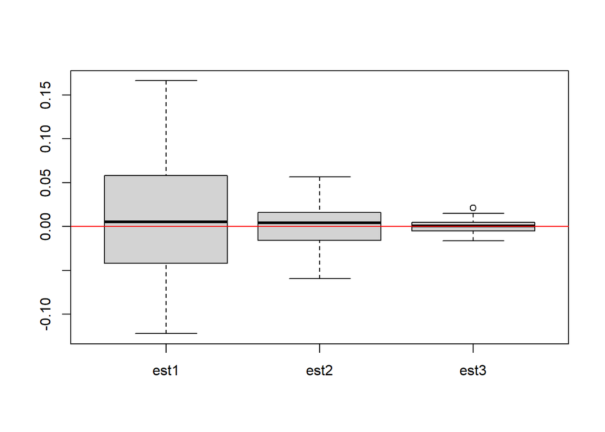

```r
# draw the boxplot for all three
boxplot(data.frame(est1, est2, est3))
abline(h = 0, col = 'red')
```

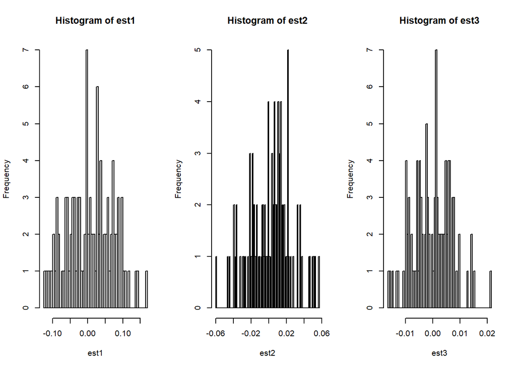

```r
# draw histgram for all three
par(mfrow = c(1, 3))
hist(est1, breaks = 100)
hist(est2, breaks = 100)
hist(est3, breaks = 100)
```

Answer: so by using Monte Carlo estimation, it seems that this is a fair game.

## Problem 2

part(a): The below codes shows the rename of variables

```r
setwd("C:/Users/Lenovo/Downloads") #set the work directory
warning('off')
data <- read.csv("cars (1).csv", header = TRUE)
names(data) <-c("D_hei",
                "D_len",
                "D_wid",
                "Edrive",
                "Eeng",
                "EHyb",
                "EFGear",
                "Etrans",
                "FCmpg",
                "Fueltype",
                "FHmpg",
                "IClass",
                "IID",
                "IMake",
                "IMyear",
                "Iyear",
                "Ehpower",
                "Etor")
```

part(b): The below code restricted our original data to those cars with fuel type of gasoline, and I renamed it to data1.

```r
data1 <- data[which(data$Fueltype == "Gasoline"), ]
```

part(c):we will do several different regressions:

```r
# The linear regression that only contain the predictor horsepower
model_1 <- lm(FHmpg ~ Ehpower, data = data1)
summary(model_1)
```

```
Call:
lm(formula = FHmpg ~ Ehpower, data = data1)

Residuals:
    Min      1Q  Median      3Q     Max
-10.673  -2.845  -0.258   2.913 200.258

Coefficients:
              Estimate Std. Error t value Pr(>|t|)
(Intercept) 34.1861498  0.2161842  158.13   <2e-16 ***
Ehpower     -0.0344689  0.0007595  -45.39   <2e-16 ***
---
Signif. codes:  0 '***' 0.001 '**' 0.01 '*' 0.05 '.' 0.1 ' ' 1

Residual standard error: 5.013 on 4589 degrees of freedom
Multiple R-squared:  0.3098,    Adjusted R-squared:  0.3097
F-statistic:  2060 on 1 and 4589 DF,  p-value: < 2.2e-16
```

If we only contain the variable of horsepower, basically our conclusion will be with one more unit horsepower, the highway mpg will decrease by 0.034 averagely, and it seems the coefficient is statistically significant.

```r
#linear model with horsepower and torque of the engine
model_2 <- lm(FHmpg ~ Ehpower + Etor, data = data1)
summary(model_2)
```

```
Call:
lm(formula = FHmpg ~ Ehpower + Etor, data = data1)

Residuals:
    Min      1Q  Median      3Q     Max
 -9.729  -2.632  -0.661   2.489 202.234

Coefficients:
             Estimate Std. Error t value Pr(>|t|)
(Intercept) 34.386412   0.202445 169.856   <2e-16 ***
Ehpower      0.019332   0.002222   8.699   <2e-16 ***
Etor        -0.054600   0.002137 -25.551   <2e-16 ***
---
Signif. codes:  0 '***' 0.001 '**' 0.01 '*' 0.05 '.' 0.1 ' ' 1

Residual standard error: 4.691 on 4588 degrees of freedom
Multiple R-squared:  0.3958,    Adjusted R-squared:  0.3955
F-statistic:  1503 on 2 and 4588 DF,  p-value: < 2.2e-16
```

Now if we contain the variable of torque, then coefficient of horsepower would be explained as: fix torque, one more unit of horsepower will increase the mpg by 0.019 averagely, and the coefficient is statistically significant.

```r
#linear model with horsepower and three dimention of the car
model_3 <- lm(FHmpg ~ Ehpower + D_hei + D_len + D_wid, data = data1)
summary(model_3)
```

```
Call:
lm(formula = FHmpg ~ Ehpower + D_hei + D_len + D_wid, data = data1)

Residuals:
    Min      1Q  Median      3Q     Max
-11.213  -2.615  -0.076   2.699 201.516

Coefficients:
              Estimate Std. Error t value Pr(>|t|)
(Intercept) 32.9747867  0.3514685  93.820  < 2e-16 ***
Ehpower     -0.0334608  0.0007537 -44.394  < 2e-16 ***
D_hei        0.0115352  0.0011995   9.617  < 2e-16 ***
D_len        0.0008645  0.0009439   0.916     0.36
D_wid       -0.0062758  0.0009286  -6.758 1.57e-11 ***
---
Signif. codes:  0 '***' 0.001 '**' 0.01 '*' 0.05 '.' 0.1 ' ' 1

Residual standard error: 4.925 on 4586 degrees of freedom
Multiple R-squared:  0.3343,    Adjusted R-squared:  0.3337
F-statistic: 575.7 on 4 and 4586 DF,  p-value: < 2.2e-16
```

Now if we contain the variable of all three dimensions, then coefficient of horsepower would be explained as: fix other variables, one more unit of horsepower will decrease the mpg by 0.0334 averagely, and the coefficient is statistically significant. Since the length seems statistically insignificant, we will remove it in the future.

```r
# linear model with horsepower and the year the car was released
data1$Iyear[data1$Iyear == 2009] <- "2009"
data1$Iyear[data1$Iyear == 2010] <- "2010"
data1$Iyear[data1$Iyear == 2011] <- "2011"
data1$Iyear[data1$Iyear == 2012] <- "2012"
model_4 <-  lm(FHmpg ~ Ehpower + Iyear, data = data1)
summary(model_4)
```

```
Call:
lm(formula = FHmpg ~ Ehpower + Iyear, data = data1)

Residuals:
    Min      1Q  Median      3Q     Max
-12.050  -2.696  -0.078   2.854 200.406

Coefficients:
              Estimate Std. Error t value Pr(>|t|)
(Intercept) 33.8534831  0.7436835  45.521   <2e-16 ***
Ehpower     -0.0344725  0.0007504 -45.936   <2e-16 ***
Iyear2010   -0.4340551  0.7244638  -0.599   0.5491
Iyear2011    0.1849839  0.7234525   0.256   0.7982
Iyear2012    1.7102720  0.7292147   2.345   0.0191 *
---
Signif. codes:  0 '***' 0.001 '**' 0.01 '*' 0.05 '.' 0.1 ' ' 1

Residual standard error: 4.946 on 4586 degrees of freedom
Multiple R-squared:  0.3285,    Adjusted R-squared:  0.3279
F-statistic: 560.9 on 4 and 4586 DF,  p-value: < 2.2e-16
```

```r
# linear model with variable of horsepower, torque of engine, height and width of the car
model_5 <- lm(FHmpg ~ Ehpower + Etor + D_hei + D_wid, data = data1)
summary(model_5)
```

```
Call:
lm(formula = FHmpg ~ Ehpower + Etor + D_hei + D_wid, data = data1)

Residuals:
    Min      1Q  Median      3Q     Max
-10.063  -2.606  -0.551   2.399 202.794

Coefficients:
              Estimate Std. Error t value Pr(>|t|)
(Intercept) 32.6657060  0.3180634 102.702  < 2e-16 ***
Ehpower      0.0181316  0.0022920   7.911 3.18e-15 ***
Etor        -0.0524688  0.0022164 -23.673  < 2e-16 ***
D_hei        0.0101964  0.0011316   9.011  < 2e-16 ***
D_wid       -0.0002471  0.0009126  -0.271    0.787
---
Signif. codes:  0 '***' 0.001 '**' 0.01 '*' 0.05 '.' 0.1 ' ' 1

Residual standard error: 4.65 on 4586 degrees of freedom
Multiple R-squared:  0.4067,    Adjusted R-squared:  0.4061
F-statistic: 785.8 on 4 and 4586 DF,  p-value: < 2.2e-16
```

Now if we contain the other 3 variables, then coefficient of horsepower would be explained as: fix other variables, one more unit of horsepower will increase the mpg by 0.0181 averagely, and the coefficient is statistically significant. Since variable D_wid seems statistically insignificant, we will remove it in the future.

```r
#last regression contains variables of Ehpower, Etor, D_hei
model_6 <- lm(FHmpg ~ Ehpower + Etor + D_hei, data = data1)
summary(model_6)
```

```
Call:
lm(formula = FHmpg ~ Ehpower + Etor + D_hei, data = data1)

Residuals:
    Min      1Q  Median      3Q     Max
-10.090  -2.618  -0.547   2.421 202.778

Coefficients:
             Estimate Std. Error t value Pr(>|t|)
(Intercept) 32.623852   0.277949 117.373   <2e-16 ***
Ehpower      0.018300   0.002205   8.298   <2e-16 ***
Etor        -0.052636   0.002129 -24.728   <2e-16 ***
D_hei        0.010244   0.001118   9.163   <2e-16 ***
---
Signif. codes:  0 '***' 0.001 '**' 0.01 '*' 0.05 '.' 0.1 ' ' 1

Residual standard error: 4.649 on 4587 degrees of freedom
Multiple R-squared:  0.4067,    Adjusted R-squared:  0.4063
F-statistic:  1048 on 3 and 4587 DF,  p-value: < 2.2e-16
```

Now if we contain the other 2 variables, then coefficient of horsepower would be explained as: fix other variables, one more unit of horsepower will increase the mpg by 0.0183 averagely, and the coefficient is statistically significant.

General conclusion: I think according common sense, higher horsepower should give us higher highway mpg, and after we removed some unnecessary variables(coefficient that is not statistically significant), the summary of last regression modelroughly tell us that given other variables unchanged, the one more unit of horsepower will increase the highway mpg 0.018 averagely. But in fact we still need to do more work to judge the causal effect since we don’t know if there are some dependency between different variables, and the R-squared we get in each model is not big enough to help us conclude if the model fit our data well.

part(d): we first do a general linear regression(here the Mpg I will understand it as highway Mpg), as the code shown below:

```r
library(emmeans)
model <- lm(Ehpower ~ FHmpg * Etor , data = data1)
summary(model)
```

```
Call:
lm(formula = Ehpower ~ FHmpg * Etor, data = data1)

Residuals:
    Min      1Q  Median      3Q     Max
-345.21  -14.22   -2.49   12.41  212.77

Coefficients:
              Estimate Std. Error t value Pr(>|t|)
(Intercept) 48.2093495  6.1191920   7.878 4.11e-15 ***
FHmpg       -1.2296667  0.2150292  -5.719 1.14e-08 ***
Etor         0.7552910  0.0183067  41.258  < 2e-16 ***
FHmpg:Etor   0.0076493  0.0007126  10.734  < 2e-16 ***
---
Signif. codes:  0 '***' 0.001 '**' 0.01 '*' 0.05 '.' 0.1 ' ' 1

Residual standard error: 30.53 on 4587 degrees of freedom
Multiple R-squared:  0.9019,    Adjusted R-squared:  0.9018
F-statistic: 1.405e+04 on 3 and 4587 DF,  p-value: < 2.2e-16
```

Now I will choose three values of torque which are 235, 236, and 350, and I will form a new dataset, which I call it data2, and then I will fit a new linear model to this new data

```r
data2 <- data1[which(data1$Etor == 235 | data1$Etor == 236 | data1$Etor == 350),]
data2$Etor <- as.factor(data2$Etor)
model_inter <- lm(Ehpower ~ FHmpg * Etor , data = data2)
summary(model_inter)
```

```
Call:
lm(formula = Ehpower ~ FHmpg * Etor, data = data2)

Residuals:
    Min      1Q  Median      3Q     Max
-31.143  -2.545  -0.234   4.838  45.194

Coefficients:
               Estimate Std. Error t value Pr(>|t|)
(Intercept)    193.5033    16.6361  11.632  < 2e-16 ***
FHmpg            0.8365     0.8048   1.039      0.3
Etor236        149.8457    18.1272   8.266 4.22e-14 ***
Etor350       -140.5092    18.7978  -7.475 4.22e-12 ***
FHmpg:Etor236   -5.0367     0.8472  -5.945 1.58e-08 ***
FHmpg:Etor350   12.4167     0.9289  13.367  < 2e-16 ***
---
Signif. codes:  0 '***' 0.001 '**' 0.01 '*' 0.05 '.' 0.1 ' ' 1

Residual standard error: 9.323 on 166 degrees of freedom
Multiple R-squared:  0.9473,    Adjusted R-squared:  0.9457
F-statistic: 596.3 on 5 and 166 DF,  p-value: < 2.2e-16
```

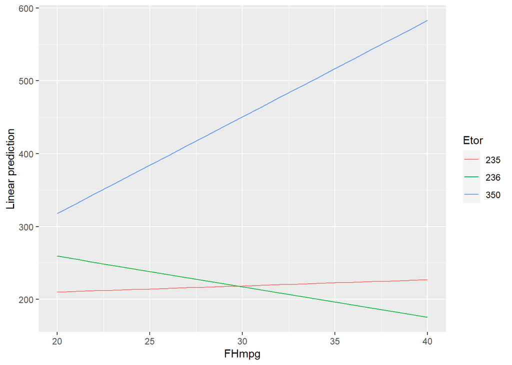

```r
# generate the interaction plot
emmip(model_inter, Etor ~ FHmpg, at = list(FHmpg = 20 : 40))
```

So it seems that there is a interaction between the highway mpg and the torque in there effect on the horsepower, because these three lines are not parallel.

part(e):

I will do the manually matrix computation for the linear model using data2.

```r
row_number <- dim(data2)[1]
intercept <- rep(1, row_number)



E235 <- rep(0, row_number)
E235[data2$Etor == 235] <- 1

E236 <- rep(0, row_number)
E236[data2$Etor == 236] <- 1

E350 <- rep(0, row_number)
E350[data2$Etor == 350] <- 1

mph235 <- data2$FHmpg * E235
mph236 <- data2$FHmpg * E236
mph350 <- data2$FHmpg * E350

X <- cbind(intercept, data2$FHmpg, E236, E350, mph236, mph350)
y <- data2$Ehpower

Xtx_inv <- solve(t(X)%*%X)
result <- (Xtx_inv)%*%t(X)%*%y
result
```

```
                 [,1]
intercept  193.503292
             0.836542
E236       149.845722
E350      -140.509171
mph236      -5.036691
mph350      12.416726
```

```r
summary(model_inter)
```

```
Call:
lm(formula = Ehpower ~ FHmpg * Etor, data = data2)

Residuals:
    Min      1Q  Median      3Q     Max
-31.143  -2.545  -0.234   4.838  45.194

Coefficients:
               Estimate Std. Error t value Pr(>|t|)
(Intercept)    193.5033    16.6361  11.632  < 2e-16 ***
FHmpg            0.8365     0.8048   1.039      0.3
Etor236        149.8457    18.1272   8.266 4.22e-14 ***
Etor350       -140.5092    18.7978  -7.475 4.22e-12 ***
FHmpg:Etor236   -5.0367     0.8472  -5.945 1.58e-08 ***
FHmpg:Etor350   12.4167     0.9289  13.367  < 2e-16 ***
---
Signif. codes:  0 '***' 0.001 '**' 0.01 '*' 0.05 '.' 0.1 ' ' 1

Residual standard error: 9.323 on 166 degrees of freedom
Multiple R-squared:  0.9473,    Adjusted R-squared:  0.9457
F-statistic: 596.3 on 5 and 166 DF,  p-value: < 2.2e-16
```

Answer : So we get exactly the same result by using manually matrix computation.